# Risk Factor Analysis

## Outcome Variable

**Outcome Variable:** wasted

## Predictor Variables

**Intervention Variable:** predfeed3

**Adjustment Set:**

- arm
- sex
- month
- brthmon
- W_mage
- meducyrs
- feducyrs
- hhwealth_quart
- hfoodsec
- W_mhtcm
- vagbrth
- W_gagebrth
- W_birthwt
- W_birthlen
- W_nrooms
- W_nchldlt5
- W_parity
- impfloor
- impsan
- safeh20
- delta_W_mage
- delta_meducyrs
- delta_feducyrs
- delta_hhwealth_quart
- delta_hfoodsec
- delta_W_mhtcm
- delta_vagbrth
- delta_W_gagebrth
- delta_W_birthwt
- delta_W_birthlen
- delta_W_nrooms
- delta_W_nchldlt5
- delta_W_parity
- delta_impfloor
- delta_impsan
- delta_safeh20

## Stratifying Variables

The analysis was stratified on these variable(s):

- agecat
- studyid
- country

## Data Summary

| agecat | studyid | country | predfeed3 | wasted | n_cell | n |
| --- | --- | --- | --- | --- | --- | --- |
| Birth | ki0047075b-MAL-ED | BANGLADESH | 1 | 0 | 160 | 227 |
| Birth | ki0047075b-MAL-ED | BANGLADESH | 1 | 1 | 33 | 227 |
| Birth | ki0047075b-MAL-ED | BANGLADESH | 0 | 0 | 29 | 227 |
| Birth | ki0047075b-MAL-ED | BANGLADESH | 0 | 1 | 5 | 227 |
| Birth | ki0047075b-MAL-ED | BRAZIL | 1 | 0 | 95 | 177 |
| Birth | ki0047075b-MAL-ED | BRAZIL | 1 | 1 | 2 | 177 |
| Birth | ki0047075b-MAL-ED | BRAZIL | 0 | 0 | 76 | 177 |
| Birth | ki0047075b-MAL-ED | BRAZIL | 0 | 1 | 4 | 177 |
| Birth | ki0047075b-MAL-ED | INDIA | 1 | 0 | 127 | 193 |
| Birth | ki0047075b-MAL-ED | INDIA | 1 | 1 | 23 | 193 |
| Birth | ki0047075b-MAL-ED | INDIA | 0 | 0 | 33 | 193 |
| Birth | ki0047075b-MAL-ED | INDIA | 0 | 1 | 10 | 193 |
| Birth | ki0047075b-MAL-ED | NEPAL | 1 | 0 | 87 | 166 |
| Birth | ki0047075b-MAL-ED | NEPAL | 1 | 1 | 10 | 166 |
| Birth | ki0047075b-MAL-ED | NEPAL | 0 | 0 | 59 | 166 |
| Birth | ki0047075b-MAL-ED | NEPAL | 0 | 1 | 10 | 166 |
| Birth | ki0047075b-MAL-ED | PERU | 1 | 0 | 173 | 265 |
| Birth | ki0047075b-MAL-ED | PERU | 1 | 1 | 4 | 265 |
| Birth | ki0047075b-MAL-ED | PERU | 0 | 0 | 86 | 265 |
| Birth | ki0047075b-MAL-ED | PERU | 0 | 1 | 2 | 265 |
| Birth | ki0047075b-MAL-ED | SOUTH AFRICA | 1 | 0 | 83 | 231 |
| Birth | ki0047075b-MAL-ED | SOUTH AFRICA | 1 | 1 | 4 | 231 |
| Birth | ki0047075b-MAL-ED | SOUTH AFRICA | 0 | 0 | 134 | 231 |
| Birth | ki0047075b-MAL-ED | SOUTH AFRICA | 0 | 1 | 10 | 231 |
| Birth | ki0047075b-MAL-ED | TANZANIA, UNITED REPUBLIC OF | 1 | 0 | 49 | 114 |
| Birth | ki0047075b-MAL-ED | TANZANIA, UNITED REPUBLIC OF | 1 | 1 | 0 | 114 |
| Birth | ki0047075b-MAL-ED | TANZANIA, UNITED REPUBLIC OF | 0 | 0 | 63 | 114 |
| Birth | ki0047075b-MAL-ED | TANZANIA, UNITED REPUBLIC OF | 0 | 1 | 2 | 114 |
| Birth | ki1000109-EE | PAKISTAN | 1 | 0 | 1 | 1 |
| Birth | ki1000109-EE | PAKISTAN | 1 | 1 | 0 | 1 |

[output cut: 94 more lines]

The following strata were considered:

- agecat: 24 months, studyid: ki0047075b-MAL-ED, country: BANGLADESH
- agecat: 24 months, studyid: ki0047075b-MAL-ED, country: BRAZIL
- agecat: 24 months, studyid: ki0047075b-MAL-ED, country: INDIA
- agecat: 24 months, studyid: ki0047075b-MAL-ED, country: NEPAL
- agecat: 24 months, studyid: ki0047075b-MAL-ED, country: PERU
- agecat: 24 months, studyid: ki0047075b-MAL-ED, country: SOUTH AFRICA
- agecat: 24 months, studyid: ki0047075b-MAL-ED, country: TANZANIA, UNITED REPUBLIC OF
- agecat: 24 months, studyid: ki1113344-GMS-Nepal, country: NEPAL
- agecat: 24 months, studyid: kiGH5241-JiVitA-3, country: BANGLADESH
- agecat: 24 months, studyid: kiGH5241-JiVitA-4, country: BANGLADESH
- agecat: 6 months, studyid: ki0047075b-MAL-ED, country: BANGLADESH
- agecat: 6 months, studyid: ki0047075b-MAL-ED, country: BRAZIL
- agecat: 6 months, studyid: ki0047075b-MAL-ED, country: INDIA
- agecat: 6 months, studyid: ki0047075b-MAL-ED, country: NEPAL
- agecat: 6 months, studyid: ki0047075b-MAL-ED, country: PERU
- agecat: 6 months, studyid: ki0047075b-MAL-ED, country: SOUTH AFRICA
- agecat: 6 months, studyid: ki0047075b-MAL-ED, country: TANZANIA, UNITED REPUBLIC OF
- agecat: 6 months, studyid: ki1000109-EE, country: PAKISTAN
- agecat: 6 months, studyid: ki1113344-GMS-Nepal, country: NEPAL
- agecat: 6 months, studyid: kiGH5241-JiVitA-3, country: BANGLADESH
- agecat: 6 months, studyid: kiGH5241-JiVitA-4, country: BANGLADESH
- agecat: Birth, studyid: ki0047075b-MAL-ED, country: BANGLADESH
- agecat: Birth, studyid: ki0047075b-MAL-ED, country: BRAZIL
- agecat: Birth, studyid: ki0047075b-MAL-ED, country: INDIA
- agecat: Birth, studyid: ki0047075b-MAL-ED, country: NEPAL
- agecat: Birth, studyid: ki0047075b-MAL-ED, country: PERU
- agecat: Birth, studyid: ki0047075b-MAL-ED, country: SOUTH AFRICA
- agecat: Birth, studyid: ki0047075b-MAL-ED, country: TANZANIA, UNITED REPUBLIC OF
- agecat: Birth, studyid: ki1000109-EE, country: PAKISTAN
- agecat: Birth, studyid: kiGH5241-JiVitA-3, country: BANGLADESH
- agecat: Birth, studyid: kiGH5241-JiVitA-4, country: BANGLADESH

### Dropped Strata

Some strata were dropped due to rare outcomes:

- agecat: Birth, studyid: ki0047075b-MAL-ED, country: BRAZIL
- agecat: Birth, studyid: ki0047075b-MAL-ED, country: PERU
- agecat: Birth, studyid: ki0047075b-MAL-ED, country: SOUTH AFRICA
- agecat: Birth, studyid: ki0047075b-MAL-ED, country: TANZANIA, UNITED REPUBLIC OF
- agecat: Birth, studyid: ki1000109-EE, country: PAKISTAN
- agecat: Birth, studyid: kiGH5241-JiVitA-4, country: BANGLADESH
- agecat: 6 months, studyid: ki0047075b-MAL-ED, country: BANGLADESH
- agecat: 6 months, studyid: ki0047075b-MAL-ED, country: BRAZIL
- agecat: 6 months, studyid: ki0047075b-MAL-ED, country: NEPAL
- agecat: 6 months, studyid: ki0047075b-MAL-ED, country: PERU
- agecat: 6 months, studyid: ki0047075b-MAL-ED, country: SOUTH AFRICA
- agecat: 6 months, studyid: ki0047075b-MAL-ED, country: TANZANIA, UNITED REPUBLIC OF
- agecat: 6 months, studyid: kiGH5241-JiVitA-4, country: BANGLADESH
- agecat: 24 months, studyid: ki0047075b-MAL-ED, country: BANGLADESH
- agecat: 24 months, studyid: ki0047075b-MAL-ED, country: BRAZIL
- agecat: 24 months, studyid: ki0047075b-MAL-ED, country: NEPAL
- agecat: 24 months, studyid: ki0047075b-MAL-ED, country: PERU
- agecat: 24 months, studyid: ki0047075b-MAL-ED, country: SOUTH AFRICA
- agecat: 24 months, studyid: ki0047075b-MAL-ED, country: TANZANIA, UNITED REPUBLIC OF
- agecat: 24 months, studyid: kiGH5241-JiVitA-4, country: BANGLADESH

## Methods Detail

We’re interested in the causal parameters $E[Y_a]$ for all values of $a \in \mathcal{A}$. These parameters represent the mean outcome if, possibly contrary to fact, we intervened to set all units to have $A=a$. Under the randomization and positivity assumptions, these are identified by the statistical parameters $\psi_a=E_W[E_{Y|A,W}(Y|A=a,W)]$. In addition, we’re interested in the mean of $Y$, $E[Y]$ under no intervention (the observed mean). We will estimate these parameters by using SuperLearner to fit the relevant likelihood factors – $E_{Y|A,W}(Y|A=a,W)$ and $p(A=a|W)$, and then updating our likelihood fit using a joint TMLE.

For unadjusted analyses ($W=\{\}$), initial likelihoods were estimated using Lrnr_glm to estimate the simple $E(Y|A)$ and Lrnr_mean to estimate $p(A)$. For adjusted analyses, a small library containing Lrnr_glmnet, Lrnr_xgboost, and Lrnr_mean was used.

Having estimated these parameters, we will then use the delta method to estimate relative risks and attributable risks relative to a prespecified baseline level of $A$.

# Results Detail

## Results Plots

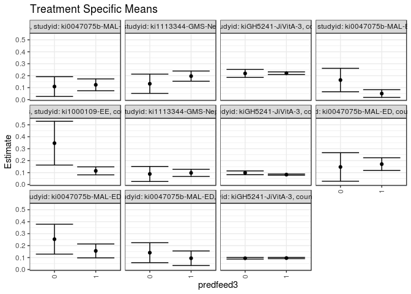

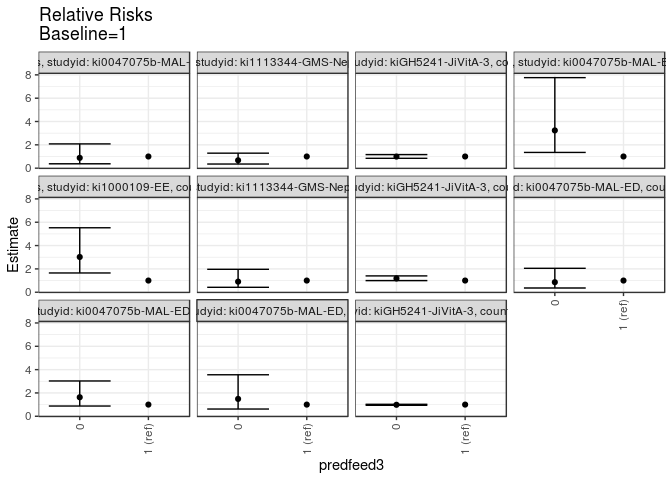

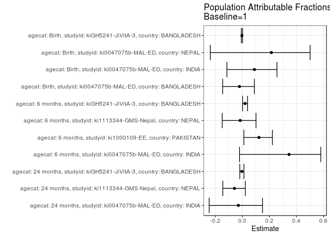

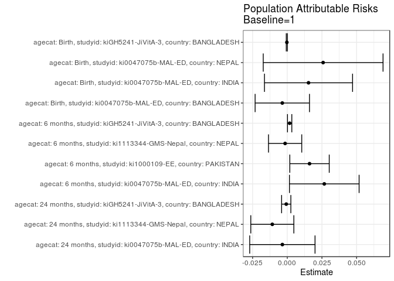

## Results Table

### Parameter: TSM

| agecat | studyid | country | intervention_level | baseline_level | estimate | ci_lower | ci_upper |
| --- | --- | --- | --- | --- | --- | --- | --- |
| Birth | ki0047075b-MAL-ED | BANGLADESH | 1 | NA | 0.1709845 | 0.1177506 | 0.2242183 |
| Birth | ki0047075b-MAL-ED | BANGLADESH | 0 | NA | 0.1470588 | 0.0277500 | 0.2663676 |
| Birth | ki0047075b-MAL-ED | INDIA | 1 | NA | 0.1556590 | 0.0976370 | 0.2136811 |
| Birth | ki0047075b-MAL-ED | INDIA | 0 | NA | 0.2537958 | 0.1288122 | 0.3787794 |
| Birth | ki0047075b-MAL-ED | NEPAL | 1 | NA | 0.0946110 | 0.0337212 | 0.1555009 |
| Birth | ki0047075b-MAL-ED | NEPAL | 0 | NA | 0.1407061 | 0.0572541 | 0.2241580 |
| Birth | kiGH5241-JiVitA-3 | BANGLADESH | 1 | NA | 0.0958231 | 0.0905525 | 0.1010937 |
| Birth | kiGH5241-JiVitA-3 | BANGLADESH | 0 | NA | 0.0942219 | 0.0876312 | 0.1008126 |
| 6 months | ki0047075b-MAL-ED | INDIA | 1 | NA | 0.0505618 | 0.0183053 | 0.0828183 |
| 6 months | ki0047075b-MAL-ED | INDIA | 0 | NA | 0.1636364 | 0.0656562 | 0.2616165 |
| 6 months | ki1000109-EE | PAKISTAN | 1 | NA | 0.1146132 | 0.0811475 | 0.1480788 |
| 6 months | ki1000109-EE | PAKISTAN | 0 | NA | 0.3461538 | 0.1630432 | 0.5292645 |
| 6 months | ki1113344-GMS-Nepal | NEPAL | 1 | NA | 0.0976253 | 0.0677111 | 0.1275396 |
| 6 months | ki1113344-GMS-Nepal | NEPAL | 0 | NA | 0.0886076 | 0.0258744 | 0.1513408 |
| 6 months | kiGH5241-JiVitA-3 | BANGLADESH | 1 | NA | 0.0831336 | 0.0780388 | 0.0882284 |
| 6 months | kiGH5241-JiVitA-3 | BANGLADESH | 0 | NA | 0.0981729 | 0.0822688 | 0.1140770 |
| 24 months | ki0047075b-MAL-ED | INDIA | 1 | NA | 0.1235294 | 0.0739565 | 0.1731024 |
| 24 months | ki0047075b-MAL-ED | INDIA | 0 | NA | 0.1090909 | 0.0265166 | 0.1916652 |
| 24 months | ki1113344-GMS-Nepal | NEPAL | 1 | NA | 0.1964286 | 0.1538951 | 0.2389621 |
| 24 months | ki1113344-GMS-Nepal | NEPAL | 0 | NA | 0.1323529 | 0.0517093 | 0.2129966 |
| 24 months | kiGH5241-JiVitA-3 | BANGLADESH | 1 | NA | 0.2208872 | 0.2101361 | 0.2316383 |
| 24 months | kiGH5241-JiVitA-3 | BANGLADESH | 0 | NA | 0.2189356 | 0.1856273 | 0.2522438 |

### Parameter: E(Y)

| agecat | studyid | country | intervention_level | baseline_level | estimate | ci_lower | ci_upper |
| --- | --- | --- | --- | --- | --- | --- | --- |
| Birth | ki0047075b-MAL-ED | BANGLADESH | NA | NA | 0.1674009 | 0.1187276 | 0.2160742 |
| Birth | ki0047075b-MAL-ED | INDIA | NA | NA | 0.1709845 | 0.1177299 | 0.2242391 |
| Birth | ki0047075b-MAL-ED | NEPAL | NA | NA | 0.1204819 | 0.0708125 | 0.1701514 |
| Birth | kiGH5241-JiVitA-3 | BANGLADESH | NA | NA | 0.0955338 | 0.0902714 | 0.1007962 |
| 6 months | ki0047075b-MAL-ED | INDIA | NA | NA | 0.0772532 | 0.0428971 | 0.1116093 |
| 6 months | ki1000109-EE | PAKISTAN | NA | NA | 0.1306667 | 0.0965090 | 0.1648243 |
| 6 months | ki1113344-GMS-Nepal | NEPAL | NA | NA | 0.0960699 | 0.0690520 | 0.1230877 |
| 6 months | kiGH5241-JiVitA-3 | BANGLADESH | NA | NA | 0.0848459 | 0.0799494 | 0.0897424 |
| 24 months | ki0047075b-MAL-ED | INDIA | NA | NA | 0.1200000 | 0.0774445 | 0.1625555 |
| 24 months | ki1113344-GMS-Nepal | NEPAL | NA | NA | 0.1856436 | 0.1476821 | 0.2236050 |
| 24 months | kiGH5241-JiVitA-3 | BANGLADESH | NA | NA | 0.2201371 | 0.2099559 | 0.2303184 |

### Parameter: RR

| agecat | studyid | country | intervention_level | baseline_level | estimate | ci_lower | ci_upper |
| --- | --- | --- | --- | --- | --- | --- | --- |
| Birth | ki0047075b-MAL-ED | BANGLADESH | 1 | 1 | 1.0000000 | 1.0000000 | 1.000000 |
| Birth | ki0047075b-MAL-ED | BANGLADESH | 0 | 1 | 0.8600713 | 0.3606934 | 2.050835 |
| Birth | ki0047075b-MAL-ED | INDIA | 1 | 1 | 1.0000000 | 1.0000000 | 1.000000 |
| Birth | ki0047075b-MAL-ED | INDIA | 0 | 1 | 1.6304599 | 0.8785188 | 3.026002 |
| Birth | ki0047075b-MAL-ED | NEPAL | 1 | 1 | 1.0000000 | 1.0000000 | 1.000000 |
| Birth | ki0047075b-MAL-ED | NEPAL | 0 | 1 | 1.4872054 | 0.6216445 | 3.557950 |
| Birth | kiGH5241-JiVitA-3 | BANGLADESH | 1 | 1 | 1.0000000 | 1.0000000 | 1.000000 |
| Birth | kiGH5241-JiVitA-3 | BANGLADESH | 0 | 1 | 0.9832895 | 0.9416206 | 1.026802 |
| 6 months | ki0047075b-MAL-ED | INDIA | 1 | 1 | 1.0000000 | 1.0000000 | 1.000000 |
| 6 months | ki0047075b-MAL-ED | INDIA | 0 | 1 | 3.2363636 | 1.3492003 | 7.763154 |
| 6 months | ki1000109-EE | PAKISTAN | 1 | 1 | 1.0000000 | 1.0000000 | 1.000000 |
| 6 months | ki1000109-EE | PAKISTAN | 0 | 1 | 3.0201923 | 1.6505346 | 5.526428 |
| 6 months | ki1113344-GMS-Nepal | NEPAL | 1 | 1 | 1.0000000 | 1.0000000 | 1.000000 |
| 6 months | ki1113344-GMS-Nepal | NEPAL | 0 | 1 | 0.9076291 | 0.4196337 | 1.963118 |
| 6 months | kiGH5241-JiVitA-3 | BANGLADESH | 1 | 1 | 1.0000000 | 1.0000000 | 1.000000 |
| 6 months | kiGH5241-JiVitA-3 | BANGLADESH | 0 | 1 | 1.1809053 | 0.9961112 | 1.399982 |
| 24 months | ki0047075b-MAL-ED | INDIA | 1 | 1 | 1.0000000 | 1.0000000 | 1.000000 |
| 24 months | ki0047075b-MAL-ED | INDIA | 0 | 1 | 0.8831169 | 0.3749247 | 2.080139 |
| 24 months | ki1113344-GMS-Nepal | NEPAL | 1 | 1 | 1.0000000 | 1.0000000 | 1.000000 |
| 24 months | ki1113344-GMS-Nepal | NEPAL | 0 | 1 | 0.6737968 | 0.3529368 | 1.286355 |
| 24 months | kiGH5241-JiVitA-3 | BANGLADESH | 1 | 1 | 1.0000000 | 1.0000000 | 1.000000 |
| 24 months | kiGH5241-JiVitA-3 | BANGLADESH | 0 | 1 | 0.9911645 | 0.8451674 | 1.162382 |

### Parameter: PAR

| agecat | studyid | country | intervention_level | baseline_level | estimate | ci_lower | ci_upper |
| --- | --- | --- | --- | --- | --- | --- | --- |
| Birth | ki0047075b-MAL-ED | BANGLADESH | 1 | NA | -0.0035836 | -0.0231834 | 0.0160162 |
| Birth | ki0047075b-MAL-ED | INDIA | 1 | NA | 0.0153254 | -0.0164440 | 0.0470948 |
| Birth | ki0047075b-MAL-ED | NEPAL | 1 | NA | 0.0258709 | -0.0173332 | 0.0690750 |
| Birth | kiGH5241-JiVitA-3 | BANGLADESH | 1 | NA | -0.0002893 | -0.0007172 | 0.0001387 |
| 6 months | ki0047075b-MAL-ED | INDIA | 1 | NA | 0.0266914 | 0.0015702 | 0.0518126 |
| 6 months | ki1000109-EE | PAKISTAN | 1 | NA | 0.0160535 | 0.0018375 | 0.0302695 |
| 6 months | ki1113344-GMS-Nepal | NEPAL | 1 | NA | -0.0015555 | -0.0135476 | 0.0104367 |
| 6 months | kiGH5241-JiVitA-3 | BANGLADESH | 1 | NA | 0.0017123 | 0.0001520 | 0.0032726 |
| 24 months | ki0047075b-MAL-ED | INDIA | 1 | NA | -0.0035294 | -0.0270864 | 0.0200275 |
| 24 months | ki1113344-GMS-Nepal | NEPAL | 1 | NA | -0.0107850 | -0.0263084 | 0.0047384 |
| 24 months | kiGH5241-JiVitA-3 | BANGLADESH | 1 | NA | -0.0007501 | -0.0040803 | 0.0025802 |

### Parameter: PAF

| agecat | studyid | country | intervention_level | baseline_level | estimate | ci_lower | ci_upper |
| --- | --- | --- | --- | --- | --- | --- | --- |
| Birth | ki0047075b-MAL-ED | BANGLADESH | 1 | NA | -0.0214071 | -0.1453552 | 0.0891275 |
| Birth | ki0047075b-MAL-ED | INDIA | 1 | NA | 0.0896304 | -0.1142100 | 0.2561791 |
| Birth | ki0047075b-MAL-ED | NEPAL | 1 | NA | 0.2147283 | -0.2366260 | 0.5013435 |
| Birth | kiGH5241-JiVitA-3 | BANGLADESH | 1 | NA | -0.0030281 | -0.0075245 | 0.0014482 |
| 6 months | ki0047075b-MAL-ED | INDIA | 1 | NA | 0.3455056 | -0.0210466 | 0.5804668 |
| 6 months | ki1000109-EE | PAKISTAN | 1 | NA | 0.1228583 | 0.0110358 | 0.2220370 |
| 6 months | ki1113344-GMS-Nepal | NEPAL | 1 | NA | -0.0161909 | -0.1489352 | 0.1012165 |
| 6 months | kiGH5241-JiVitA-3 | BANGLADESH | 1 | NA | 0.0201812 | 0.0016154 | 0.0384017 |
| 24 months | ki0047075b-MAL-ED | INDIA | 1 | NA | -0.0294118 | -0.2454450 | 0.1491486 |
| 24 months | ki1113344-GMS-Nepal | NEPAL | 1 | NA | -0.0580952 | -0.1446338 | 0.0219007 |
| 24 months | kiGH5241-JiVitA-3 | BANGLADESH | 1 | NA | -0.0034073 | -0.0186488 | 0.0116061 |